# WLE_classification

Stephanie_Lee_S

3/7/2021

## Load Data and Take a Look at the Class Distribution

Here, we load the train and the test data set,

```r
library(caret)
```

```r
train_and_test = read.csv('https://d396qusza40orc.cloudfront.net/predmachlearn/pml-training.csv')
val_set = read.csv('https://d396qusza40orc.cloudfront.net/predmachlearn/pml-testing.csv')
```

and then delete variables from `train_and_test` data set. The deleted variables are variables which has no data at all in the validation data set. This is my first step of preprocess the data sets. The resulting data sets now have 60 variables.

```r
for (i in 1:length(names(val_set))){
    if (class(val_set[,i])=='logical'){
        val_set[,i] <- as.numeric(val_set[,i])
    }
} #converting any logical variables into numeric

nacols <- colnames(val_set)[apply(val_set, 2, anyNA)]
train_and_test <- train_and_test[, !(names(train_and_test) %in% nacols)]
val_set <- val_set[, !(names(val_set) %in% nacols)]
```

Next, I split `train_and_test` data frame into `training_set` and `testing_set`.

```r
set.seed(29123)
inTrain = createDataPartition(train_and_test$classe, p = .75,list = F)
training_set = train_and_test[inTrain,]
testing_set = train_and_test[-inTrain,]
```

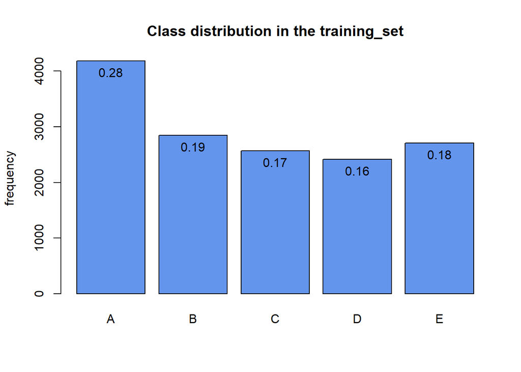

```r
freq <- round(prop.table(table(training_set$classe)), 2)
plot <- plot(training_set$classe, col = 'cornflowerblue',
             ylab = 'frequency', main = 'Class distribution in the training_set')
text(plot, table(training_set$classe), labels = freq, pos = 1)
```

## Further Data Preprocessing

```r
zv <- nearZeroVar(training_set)
training_set <- training_set[, -c(1:7,zv)] #removing near zero variables
testing_set <- testing_set[, -c(1:7,zv)]
val_set <- val_set[,-c(1:7,zv)]
```

## Training Models

Before we train any model, we need to setup the how `train()` in caret fit models to make training goes faster. I use 5-fold cross validation to train models.

```r
trControl <- trainControl(method = 'cv', number = 5, allowParallel = T)
```

### Models Used in this Analysis

I used four models to train data, including k-nearest neighbors, boosting, bagging, and random forest. The predictions from these models would be combined together, and then I use majority vote to decide the classification. In training models, I use all the default tuning parameter, except for how R train the models. The final model is chosen based on the accuracy.

#### K Nearest Neighbors

```r
set.seed(8954)
model_knn = train(classe~., data = training_set, method = 'knn',
                  trControl = trControl)
model_knn
```

```
## k-Nearest Neighbors
##
## 14718 samples
##    52 predictor
##     5 classes: 'A', 'B', 'C', 'D', 'E'
##
## No pre-processing
## Resampling: Cross-Validated (5 fold)
## Summary of sample sizes: 11774, 11774, 11775, 11775, 11774
## Resampling results across tuning parameters:
##
##   k  Accuracy   Kappa
##   5  0.8937371  0.8655336
##   7  0.8697520  0.8351442
##   9  0.8522224  0.8129236
##
## Accuracy was used to select the optimal model using the largest value.
## The final value used for the model was k = 5.
```

#### Boosting

```r
set.seed(9045)
model_gbm = train(classe~., data = training_set, method = 'gbm',
                  trControl = trControl, verbose = F)
model_gbm
```

```
## Stochastic Gradient Boosting
##
## 14718 samples
##    52 predictor
##     5 classes: 'A', 'B', 'C', 'D', 'E'
##
## No pre-processing
## Resampling: Cross-Validated (5 fold)
## Summary of sample sizes: 11775, 11774, 11774, 11775, 11774
## Resampling results across tuning parameters:
##
##   interaction.depth  n.trees  Accuracy   Kappa
##   1                   50      0.7525468  0.6863884
##   1                  100      0.8249757  0.7785079
##   1                  150      0.8548710  0.8163441
##   2                   50      0.8548712  0.8161463
##   2                  100      0.9068481  0.8821008
##   2                  150      0.9317158  0.9135957
##   3                   50      0.8940747  0.8659265
##   3                  100      0.9419758  0.9265768
##   3                  150      0.9623588  0.9523747
##
## Tuning parameter 'shrinkage' was held constant at a value of 0.1
##
## Tuning parameter 'n.minobsinnode' was held constant at a value of 10
## Accuracy was used to select the optimal model using the largest value.
## The final values used for the model were n.trees = 150, interaction.depth =
##  3, shrinkage = 0.1 and n.minobsinnode = 10.
```

#### Bagging

```r
set.seed(9090)
model_bag = train(classe~., data = training_set, method = 'treebag',
                  trControl = trControl)
model_bag
```

```
## Bagged CART
##
## 14718 samples
##    52 predictor
##     5 classes: 'A', 'B', 'C', 'D', 'E'
##
## No pre-processing
## Resampling: Cross-Validated (5 fold)
## Summary of sample sizes: 11774, 11775, 11774, 11775, 11774
## Resampling results:
##
##   Accuracy  Kappa
##   0.980908  0.9758483
```

#### Random Forest

```r
set.seed(120552)
model_rf = train(classe~., data = training_set, method = 'rf',
                 trControl = trControl)
model_rf
```

```
## Random Forest
##
## 14718 samples
##    52 predictor
##     5 classes: 'A', 'B', 'C', 'D', 'E'
##
## No pre-processing
## Resampling: Cross-Validated (5 fold)
## Summary of sample sizes: 11774, 11775, 11775, 11774, 11774
## Resampling results across tuning parameters:
##
##   mtry  Accuracy   Kappa
##    2    0.9920506  0.9899441
##   27    0.9916429  0.9894283
##   52    0.9836257  0.9792871
##
## Accuracy was used to select the optimal model using the largest value.
## The final value used for the model was mtry = 2.
```

### Stacking Models and Majority Vote

The next step is voting, and we are going to see how good these classifiers are in predicting the categories in weight lifting exercises. Firstly, I predict each model on the testing_set, then put it together in a data frame. Since we have four models, we have four variables of `preds`.

```r
preds <- data.frame(knn = predict(model_knn, testing_set[, -59]),
                    gbm = predict(model_gbm, testing_set[, -59]),
                    bag = predict(model_bag, testing_set[, -59]),
                    rf = predict(model_rf, testing_set[, -59]))
```

Secondly, I make a function `majority()` to look for the majority vote. I use `which.max()` function with the default of returning the first value with the majority vote. The function `majority()` would be applied to each row in `preds`.

```r
majority <- function(x, vote = c()){
    row = as.factor(x)
    classes <- levels(row)
    vote <- classes[which.max(table(row))]
    vote
}
```

```r
finalVote <- apply(preds, 1, majority)
finalVote <- as.factor(finalVote)
confusionMatrix(finalVote, testing_set$classe)
```

```
## Confusion Matrix and Statistics
##
##           Reference
## Prediction    A    B    C    D    E
##          A 1392    4    0    0    2
##          B    2  940   12    0    3
##          C    1    5  843   15    1
##          D    0    0    0  787    3
##          E    0    0    0    2  892
##
## Overall Statistics
##
##                Accuracy : 0.9898
##                  95% CI : (0.9866, 0.9924)
##     No Information Rate : 0.2845
##     P-Value [Acc > NIR] : < 2.2e-16
##
##                   Kappa : 0.9871
##
##  Mcnemar's Test P-Value : NA
##
## Statistics by Class:
##
##                      Class: A Class: B Class: C Class: D Class: E
## Sensitivity            0.9978   0.9905   0.9860   0.9789   0.9900
## Specificity            0.9983   0.9957   0.9946   0.9993   0.9995
## Pos Pred Value         0.9957   0.9822   0.9746   0.9962   0.9978
## Neg Pred Value         0.9991   0.9977   0.9970   0.9959   0.9978
## Prevalence             0.2845   0.1935   0.1743   0.1639   0.1837
## Detection Rate         0.2838   0.1917   0.1719   0.1605   0.1819
## Detection Prevalence   0.2851   0.1951   0.1764   0.1611   0.1823
## Balanced Accuracy      0.9981   0.9931   0.9903   0.9891   0.9948
```

We can see here that the accuracy of combined classifiers is 98.9804241 percent. This is the out of sample accuracy (remember that accuracy is a way to assess model performance on testing and validation data sets, especially in classification problems). We are going to use the same voting system to predict the labels in the validation data set.

## Prediction

```r
predtest_knn = predict(model_knn, val_set[,-59])
predtest_gbm = predict(model_gbm, val_set[,-59])
predtest_bag = predict(model_bag, val_set[,-59])
predtest_rf = predict(model_rf, val_set[,-59])
predstest = data.frame(knn = predtest_knn,
                       gbm = predtest_gbm,
                       bag = predtest_bag,
                       rf = predtest_rf)
#apply(predstest, 1, majority) #the answer to the prediction quiz
```